# The Health and Economic Consequences of Storms

Matthew Hayes

## Data Processing

The original dataset, [found here](https://d396qusza40orc.cloudfront.net/repdata%2Fdata%2FStormData.csv.bz2), is very expansive and we won’t need all of it for this analysis. A little pre-processing will make the data much more workable.

First our packages:

```r
library(dplyr)
library(tidyr)
```

It’s important to note that `NA` values in this dataset are represented by empty strings.

```r
storm <- tbl_df(read.csv("./storm.csv.bz2", stringsAsFactors = FALSE,
                         na.strings = c(NA, "")
))
storm
```

```
## Source: local data frame [902,297 x 37]
##
##    STATE__           BGN_DATE BGN_TIME TIME_ZONE COUNTY COUNTYNAME STATE
## 1        1  4/18/1950 0:00:00     0130       CST     97     MOBILE    AL
## 2        1  4/18/1950 0:00:00     0145       CST      3    BALDWIN    AL
## 3        1  2/20/1951 0:00:00     1600       CST     57    FAYETTE    AL
## 4        1   6/8/1951 0:00:00     0900       CST     89    MADISON    AL
## 5        1 11/15/1951 0:00:00     1500       CST     43    CULLMAN    AL
## 6        1 11/15/1951 0:00:00     2000       CST     77 LAUDERDALE    AL
## 7        1 11/16/1951 0:00:00     0100       CST      9     BLOUNT    AL
## 8        1  1/22/1952 0:00:00     0900       CST    123 TALLAPOOSA    AL
## 9        1  2/13/1952 0:00:00     2000       CST    125 TUSCALOOSA    AL
## 10       1  2/13/1952 0:00:00     2000       CST     57    FAYETTE    AL
## ..     ...                ...      ...       ...    ...        ...   ...
## Variables not shown: EVTYPE (chr), BGN_RANGE (dbl), BGN_AZI (chr),
##   BGN_LOCATI (chr), END_DATE (chr), END_TIME (chr), COUNTY_END (dbl),
##   COUNTYENDN (lgl), END_RANGE (dbl), END_AZI (chr), END_LOCATI (chr),
##   LENGTH (dbl), WIDTH (dbl), F (int), MAG (dbl), FATALITIES (dbl),
##   INJURIES (dbl), PROPDMG (dbl), PROPDMGEXP (chr), CROPDMG (dbl),
##   CROPDMGEXP (chr), WFO (chr), STATEOFFIC (chr), ZONENAMES (chr), LATITUDE
##   (dbl), LONGITUDE (dbl), LATITUDE_E (dbl), LONGITUDE_ (dbl), REMARKS
##   (chr), REFNUM (dbl)
```

We’ll only need seven variables: `EVTYPE`, `FATALITIES`, `INJURIES`, `PROPDMG`, `PROPDMGEXP`, `CROPDMG`, and `CROPDMGEXP`.

```r
storm <- storm %>%
    select(EVTYPE, FATALITIES:CROPDMGEXP)
names(storm) <- tolower(names(storm))
storm
```

```
## Source: local data frame [902,297 x 7]
##
##     evtype fatalities injuries propdmg propdmgexp cropdmg cropdmgexp
## 1  TORNADO          0       15    25.0          K       0         NA
## 2  TORNADO          0        0     2.5          K       0         NA
## 3  TORNADO          0        2    25.0          K       0         NA
## 4  TORNADO          0        2     2.5          K       0         NA
## 5  TORNADO          0        2     2.5          K       0         NA
## 6  TORNADO          0        6     2.5          K       0         NA
## 7  TORNADO          0        1     2.5          K       0         NA
## 8  TORNADO          0        0     2.5          K       0         NA
## 9  TORNADO          1       14    25.0          K       0         NA
## 10 TORNADO          0        0    25.0          K       0         NA
## ..     ...        ...      ...     ...        ...     ...        ...
```

According to the [storm data documentation](https://d396qusza40orc.cloudfront.net/repdata%2Fpeer2_doc%2Fpd01016005curr.pdf), the variables `propdmgexp` and `cropdmgexp` are multipliers, where K = thousands, M = millions, and B = billions. Do they take any other values in our data set?

```r
unique(storm$propdmgexp)
```

```
##  [1] "K" "M" NA  "B" "m" "+" "0" "5" "6" "?" "4" "2" "3" "h" "7" "H" "-"
## [18] "1" "8"
```

```r
unique(storm$cropdmgexp)
```

```
## [1] NA  "M" "K" "m" "B" "?" "0" "k" "2"
```

Looks like we have some data entry issues. Given this, we need to remove any records that do not match our known multipliers.

```r
storm <- mutate(storm, propdmgexp = tolower(propdmgexp),
                cropdmgexp = tolower(propdmgexp))
good <- c("k", "m", "b", NA)
gProp <- storm$propdmgexp %in% good
gCrop <- storm$cropdmgexp %in% good
storm$propdmgexp[!gProp] <- NA
storm$cropdmgexp[!gCrop] <- NA
rm(good, gProp, gCrop)
unique(storm$propdmgexp)
```

```
## [1] "k" "m" NA  "b"
```

```r
unique(storm$cropdmgexp)
```

```
## [1] "k" "m" NA  "b"
```

Let’s convert these multipliers to their respective numerical equivalents and use them to find the true values of property and crop damage.

```r
storm <- storm %>%
    mutate(propdmgexp = gsub("k", 1000, propdmgexp),
           propdmgexp = gsub("m", 1000000, propdmgexp),
           propdmgexp = gsub("b", 1000000000, propdmgexp),
           cropdmgexp = gsub("k", 1000, cropdmgexp),
           cropdmgexp = gsub("m", 1000000, cropdmgexp),
           cropdmgexp = gsub("b", 1000000000, cropdmgexp),
           propdmgexp = as.numeric(propdmgexp),
           cropdmgexp = as.numeric(cropdmgexp),
           propdmg = propdmg * propdmgexp,
           cropdmg = cropdmg * cropdmgexp
    ) %>%
    select(-propdmgexp, -cropdmgexp)
storm
```

```
## Source: local data frame [902,297 x 5]
##
##     evtype fatalities injuries propdmg cropdmg
## 1  TORNADO          0       15   25000       0
## 2  TORNADO          0        0    2500       0
## 3  TORNADO          0        2   25000       0
## 4  TORNADO          0        2    2500       0
## 5  TORNADO          0        2    2500       0
## 6  TORNADO          0        6    2500       0
## 7  TORNADO          0        1    2500       0
## 8  TORNADO          0        0    2500       0
## 9  TORNADO          1       14   25000       0
## 10 TORNADO          0        0   25000       0
## ..     ...        ...      ...     ...     ...
```

I prefer working with tall datasets. Let’s tidy the dataset by gathering fatalities and injuries, as well as property and crop damage.

```r
storm <- storm %>%
    gather(dmgType, dmgCount, -(evtype:injuries)) %>%
    gather(injType, injCount, -evtype, -(dmgType:dmgCount))
storm
```

```
## Source: local data frame [3,609,188 x 5]
##
##     evtype dmgType dmgCount    injType injCount
## 1  TORNADO propdmg    25000 fatalities        0
## 2  TORNADO propdmg     2500 fatalities        0
## 3  TORNADO propdmg    25000 fatalities        0
## 4  TORNADO propdmg     2500 fatalities        0
## 5  TORNADO propdmg     2500 fatalities        0
## 6  TORNADO propdmg     2500 fatalities        0
## 7  TORNADO propdmg     2500 fatalities        0
## 8  TORNADO propdmg     2500 fatalities        0
## 9  TORNADO propdmg    25000 fatalities        1
## 10 TORNADO propdmg    25000 fatalities        0
## ..     ...     ...      ...        ...      ...
```

## Health Consequences

Across the United States, which types of events are most harmful with respect to population health? For this analysis, we’ll use `fatalities` and `injuries` to represent health consequences.

We’ll need some extra packages.

```r
library(ggplot2)
library(gridExtra)
```

Using our `storm` data, let’s look at total and mean fatalities/injuries by event type.

```r
health <- storm %>%
    group_by(evtype, injType) %>%
    summarize(total = sum(injCount, na.rm = TRUE),
              avg = mean(injCount, na.rm = TRUE)
    ) %>%
    ungroup()
health
```

```
## Source: local data frame [1,970 x 4]
##
##                   evtype    injType total avg
## 1     HIGH SURF ADVISORY fatalities     0   0
## 2     HIGH SURF ADVISORY   injuries     0   0
## 3          COASTAL FLOOD fatalities     0   0
## 4          COASTAL FLOOD   injuries     0   0
## 5            FLASH FLOOD fatalities     0   0
## 6            FLASH FLOOD   injuries     0   0
## 7              LIGHTNING fatalities     0   0
## 8              LIGHTNING   injuries     0   0
## 9              TSTM WIND fatalities     0   0
## 10             TSTM WIND   injuries     0   0
## ..                   ...        ...   ... ...
```

What are the top three “killer” storms, in total and on average?

```r
fatTotal <- health %>%
    filter(injType == "fatalities") %>%
    arrange(desc(total)) %>%
    head(3)
fatTotal
```

```
## Source: local data frame [3 x 4]
##
##           evtype    injType total        avg
## 1        TORNADO fatalities 11266 0.09287410
## 2 EXCESSIVE HEAT fatalities  3806 1.13408820
## 3    FLASH FLOOD fatalities  1956 0.01801868
```

```r
fatAvg <- health %>%
    filter(injType == "fatalities") %>%
    arrange(desc(avg)) %>%
    head(3)
fatAvg
```

```
## Source: local data frame [3 x 4]
##
##                       evtype    injType total avg
## 1 TORNADOES, TSTM WIND, HAIL fatalities    50  25
## 2              COLD AND SNOW fatalities    28  14
## 3      TROPICAL STORM GORDON fatalities    16   8
```

```r
injTotal<- health %>%
    filter(injType == "injuries") %>%
    arrange(desc(total))  %>%
    head(3)
injTotal
```

```
## Source: local data frame [3 x 4]
##
##      evtype  injType  total        avg
## 1   TORNADO injuries 182692 1.50606740
## 2 TSTM WIND injuries  13914 0.03163135
## 3     FLOOD injuries  13578 0.26806444
```

```r
injAvg <- health %>%
    filter(injType == "injuries") %>%
    arrange(desc(avg)) %>%
    head(3)
injAvg
```

```
## Source: local data frame [3 x 4]
##
##                  evtype  injType total  avg
## 1             Heat Wave injuries   140 70.0
## 2 TROPICAL STORM GORDON injuries    86 43.0
## 3            WILD FIRES injuries   300 37.5
```

While tornados have also injured by far the most people, it appears that heat waves, on average, produce the most injuries.

Let’s visualize these findings.

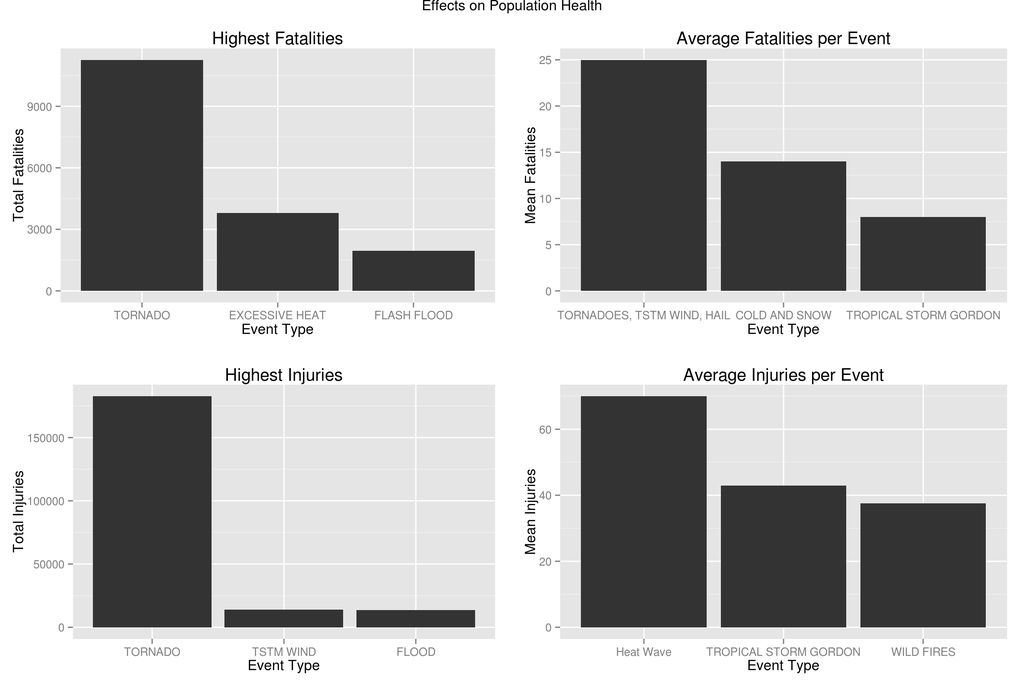

```r
h1 <- ggplot(fatTotal, aes(x = reorder(evtype, -total), y = total)) +
    geom_bar(stat = "identity") +
    labs(x = "Event Type", y = "Total Fatalities", title = "Highest Fatalities")
h2 <- ggplot(fatAvg, aes(x = reorder(evtype, -avg), y = avg)) +
    geom_bar(stat = "identity") +
    labs(x = "Event Type", y = "Mean Fatalities",
         title = "Average Fatalities per Event")
h3 <- ggplot(injTotal, aes(x = reorder(evtype, -total), y = total)) +
    geom_bar(stat = "identity") +
    labs(x = "Event Type", y = "Total Injuries", title = "Highest Injuries")
h4 <- ggplot(injAvg, aes(x = reorder(evtype, -avg), y = avg)) +
    geom_bar(stat = "identity") +
    labs(x = "Event Type", y = "Mean Injuries",
         title = "Average Injuries per Event")
grid.arrange(arrangeGrob(h1, h2, h3, h4, main = "Effects on Population Health"))
```

## Economic Consequences

Across the United States, which types of events have the greatest economic consequences? We’ll use `propdmg` and `cropdmg` as proxies for economic damage.

As we did with `health`, let’s look at total and mean property/crop damage by event type.

```r
econ <- storm %>%
    group_by(evtype, dmgType) %>%
    summarize(total = sum(dmgCount, na.rm = TRUE),
              avg = mean(dmgCount, na.rm = TRUE)
    ) %>%
    ungroup()
econ
```

```
## Source: local data frame [1,970 x 4]
##
##                   evtype dmgType    total     avg
## 1     HIGH SURF ADVISORY propdmg   400000  200000
## 2     HIGH SURF ADVISORY cropdmg        0       0
## 3          COASTAL FLOOD propdmg        0     NaN
## 4          COASTAL FLOOD cropdmg        0     NaN
## 5            FLASH FLOOD propdmg   100000   50000
## 6            FLASH FLOOD cropdmg        0       0
## 7              LIGHTNING propdmg        0     NaN
## 8              LIGHTNING cropdmg        0     NaN
## 9              TSTM WIND propdmg 16200000 4050000
## 10             TSTM WIND cropdmg        0       0
## ..                   ...     ...      ...     ...
```

Which storms are the most costly with respect to property?

```r
propTotal <- econ %>%
    filter(dmgType == "propdmg") %>%
    arrange(desc(total)) %>%
    head(3)
propTotal
```

```
## Source: local data frame [3 x 4]
##
##              evtype dmgType        total       avg
## 1             FLOOD propdmg 289315419600   8316529
## 2 HURRICANE/TYPHOON propdmg 138611680000 990083429
## 3           TORNADO propdmg 113874320960   1098600
```

```r
propAvg <- econ %>%
    filter(dmgType == "propdmg") %>%
    arrange(desc(avg)) %>%
    head(3)
propAvg
```

```
## Source: local data frame [3 x 4]
##
##                       evtype dmgType        total        avg
## 1  HEAVY RAIN/SEVERE WEATHER propdmg   5000000000 2500000000
## 2 TORNADOES, TSTM WIND, HAIL propdmg   3200000000 1600000000
## 3          HURRICANE/TYPHOON propdmg 138611680000  990083429
```

Taken loosely, too much water and wind is a very bad thing when it comes to property. Does this hold true for crop damage as well?

```r
cropTotal<- econ %>%
    filter(dmgType == "cropdmg") %>%
    arrange(desc(total))  %>%
    head(3)
cropTotal
```

```
## Source: local data frame [3 x 4]
##
##              evtype dmgType        total         avg
## 1         HURRICANE cropdmg 1.605764e+12  6372078698
## 2 HURRICANE/TYPHOON cropdmg 1.465537e+12 10468120733
## 3             FLOOD cropdmg 1.745039e+11     5016211
```

```r
cropAvg <- econ %>%
    filter(dmgType == "cropdmg") %>%
    arrange(desc(avg)) %>%
    head(3)
cropAvg
```

```
## Source: local data frame [3 x 4]
##
##                      evtype dmgType        total         avg
## 1         HURRICANE/TYPHOON cropdmg 1.465537e+12 10468120733
## 2 HURRICANE OPAL/HIGH WINDS cropdmg 2.000000e+10 10000000000
## 3                 HURRICANE cropdmg 1.605764e+12  6372078698
```

Most definitely. Unlike health consequences, economic consequences tend to be consistent across property and crops, as well as in total and on average.

Let’s visualize our results.

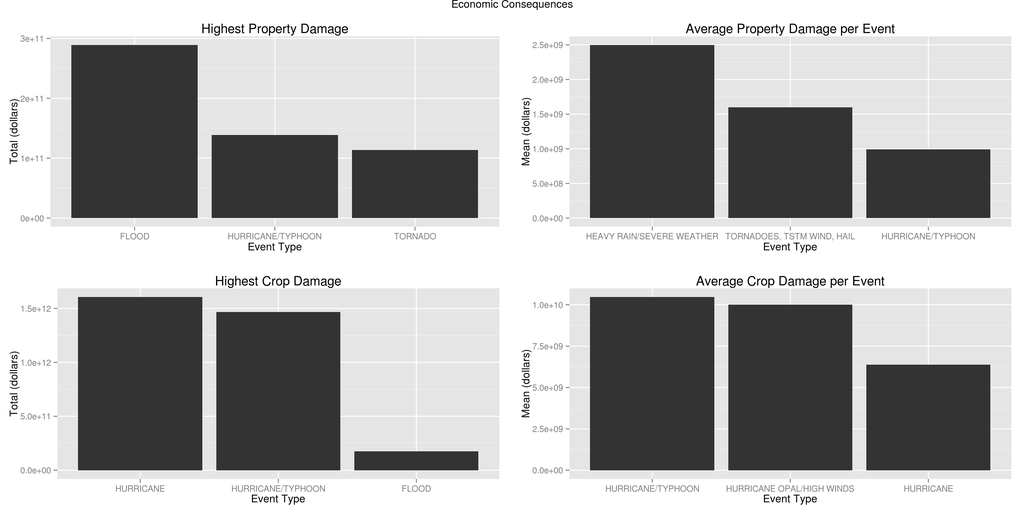

```r
e1 <- ggplot(propTotal, aes(x = reorder(evtype, -total), y = total)) +
    geom_bar(stat = "identity") +
    labs(x = "Event Type", y = "Total (dollars)",
         title = "Highest Property Damage")
e2 <- ggplot(propAvg, aes(x = reorder(evtype, -avg), y = avg)) +
    geom_bar(stat = "identity") +
    labs(x = "Event Type", y = "Mean (dollars)",
         title = "Average Property Damage per Event")
e3 <- ggplot(cropTotal, aes(x = reorder(evtype, -total), y = total)) +
    geom_bar(stat = "identity") +
    labs(x = "Event Type", y = "Total (dollars)",
         title = "Highest Crop Damage")
e4 <- ggplot(cropAvg, aes(x = reorder(evtype, -avg), y = avg)) +
    geom_bar(stat = "identity") +
    labs(x = "Event Type", y = "Mean (dollars)",
         title = "Average Crop Damage per Event")
grid.arrange(arrangeGrob(e1, e2, e3, e4, main = "Economic Consequences"))
```

## Results

Across the United States, which types of events are more costly with respect to human health and economic well-being? We’ll combine `fatalities` and `injuries` to represent human health. Economic well-being will be represented by combining `propdmg` and `cropdmg`.

First let’s combine our data.

```r
healthCombo <- health %>%
    group_by(evtype) %>%
    summarize(total = sum(total),
              avg = mean(avg)) %>%
    ungroup()
healthCombo
```

```
## Source: local data frame [985 x 3]
##
##                   evtype total avg
## 1     HIGH SURF ADVISORY     0   0
## 2          COASTAL FLOOD     0   0
## 3            FLASH FLOOD     0   0
## 4              LIGHTNING     0   0
## 5              TSTM WIND     0   0
## 6        TSTM WIND (G45)     0   0
## 7             WATERSPOUT     0   0
## 8                   WIND     0   0
## 9                      ?     0   0
## 10       ABNORMAL WARMTH     0   0
## ..                   ...   ... ...
```

```r
econCombo <- econ %>%
    group_by(evtype) %>%
    summarize(total = sum(total),
              avg = mean(avg)) %>%
    ungroup()
econCombo
```

```
## Source: local data frame [985 x 3]
##
##                   evtype    total     avg
## 1     HIGH SURF ADVISORY   400000  100000
## 2          COASTAL FLOOD        0     NaN
## 3            FLASH FLOOD   100000   25000
## 4              LIGHTNING        0     NaN
## 5              TSTM WIND 16200000 2025000
## 6        TSTM WIND (G45)    16000    4000
## 7             WATERSPOUT        0     NaN
## 8                   WIND        0     NaN
## 9                      ?    10000    2500
## 10       ABNORMAL WARMTH        0     NaN
## ..                   ...      ...     ...
```

Next, we’ll look at the top three offenders in each category.

```r
healthComboTotal <-healthCombo %>%
    arrange(desc(total)) %>%
    head(3)
healthComboTotal
```

```
## Source: local data frame [3 x 3]
##
##           evtype  total        avg
## 1        TORNADO 193958 0.79947075
## 2 EXCESSIVE HEAT  16856 2.51132300
## 3      TSTM WIND  14922 0.01696144
```

```r
healthComboAvg <-healthCombo %>%
    arrange(desc(avg)) %>%
    head(3)
healthComboAvg
```

```
## Source: local data frame [3 x 3]
##
##                  evtype total    avg
## 1             Heat Wave   140 35.000
## 2 TROPICAL STORM GORDON   102 25.500
## 3            WILD FIRES   306 19.125
```

```r
econComboTotal <- econCombo %>%
    arrange(desc(total)) %>%
    head(3)
econComboTotal
```

```
## Source: local data frame [3 x 3]
##
##              evtype        total        avg
## 1         HURRICANE 1.629500e+12 3233135853
## 2 HURRICANE/TYPHOON 1.604149e+12 5729102081
## 3             FLOOD 4.638194e+11    6666370
```

```r
econComboAvg <- econCombo %>%
    arrange(desc(avg)) %>%
    head(3)
econComboAvg
```

```
## Source: local data frame [3 x 3]
##
##                      evtype        total        avg
## 1         HURRICANE/TYPHOON 1.604149e+12 5729102081
## 2 HURRICANE OPAL/HIGH WINDS 2.020000e+10 5050000000
## 3                 HURRICANE 1.629500e+12 3233135853
```

Tornados result in the most harm by far, but on average one should be more concerned with heat waves, tropical storms, and wildfires.

As for economic consequences, it can’t be said enough: Water and wind are costly.

Finally, let’s visualize it.

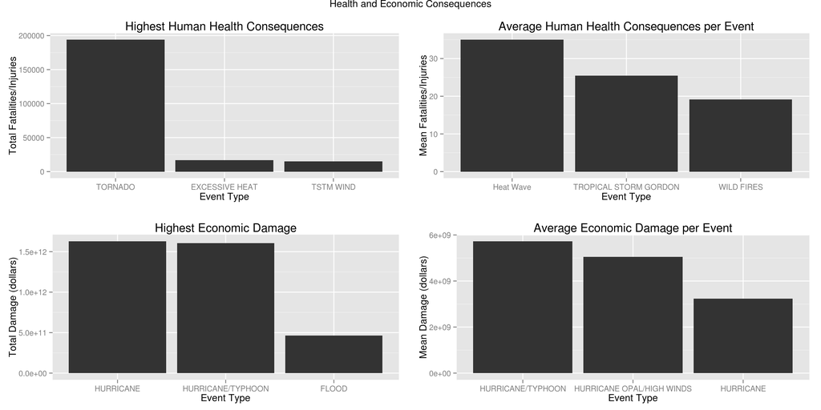

```r
c1 <- ggplot(healthComboTotal, aes(x = reorder(evtype, -total), y = total)) +
    geom_bar(stat = "identity") +
    labs(x = "Event Type", y = "Total Fatalities/Injuries",
         title = "Highest Human Health Consequences")
c2 <- ggplot(healthComboAvg, aes(x = reorder(evtype, -avg), y = avg)) +
    geom_bar(stat = "identity") +
    labs(x = "Event Type", y = "Mean Fatalities/Injuries",
         title = "Average Human Health Consequences per Event")
c3 <- ggplot(econComboTotal, aes(x = reorder(evtype, -total), y = total)) +
    geom_bar(stat = "identity") +
    labs(x = "Event Type", y = "Total Damage (dollars)",
         title = "Highest Economic Damage")
c4 <- ggplot(econComboAvg, aes(x = reorder(evtype, -avg), y = avg)) +
    geom_bar(stat = "identity") +
    labs(x = "Event Type", y = "Mean Damage (dollars)",
         title = "Average Economic Damage per Event")
grid.arrange(arrangeGrob(c1, c2, c3, c4,
                         main = "Health and Economic Consequences"))
```